# Adjustment of Labor Markets to Robots | Journal of the European Economic Association | Oxford Academic

## 1. Introduction

How have new automation technologies, such as industrial robots, transformed the labor market? Theoretical work on this question has identified two main impacts on employment and wages (Acemoglu and Restrepo 2018b, 2019). At first, the adoption of automation technologies causes a displacement effect, as robots take over tasks performed by humans. Sooner or later, however, productivity gains lead to new jobs elsewhere in the economy. Careful empirical work is now needed to provide evidence on those two channels. Furthermore, understanding and examining the underlying mechanisms is crucial for a wide range of policy questions currently high on the agenda. Displacements can trigger painful adjustments and large earnings losses (Jacobson, LaLonde, and Sullivan 1993), which might imply a bigger role for policies targeting those hurt by automation technologies. Moreover, incumbent workers might need to be re-trained in order to transition smoothly into new jobs, while young labor market entrants might adapt their educational choices in anticipation of how technologies have affected labor demand. Finally, different labor market institutions might mediate the displacement and productivity effects very differently, thus providing potential lessons how to maximize the positive impacts for society.

In this paper, we examine how firms and individual workers adjust to automation exposure. The labor-replacing technology we focus on are industrial robots, primarily used in the manufacturing sector. Following significant technological advances, robotic capabilities have made great strides in limiting the need for human intervention while autonomously operating production processes. According to the International Federation of Robotics (2016), the stock of industrial robots rose by a factor of 5 between 1993 and 2015 in North America, Europe, and Asia. An estimated 1.5 million industrial robots are currently used. A large number of industries have already undergone dramatic changes in the organization of production in the last two decades, and labor markets were deeply affected.

We use Germany as our “laboratory” and make use of local labor market variation as our main source. It is clear that Germany provides an important benchmark case when it comes to the equilibrium effects of how labor markets adjust to the rise of automation technologies. Figure 1 shows the penetration of robots, dividing their stock by the number of workers in different regions of the world between 1994 and 2014. Korea (the world leader) and Germany are technologically much more advanced in robotics than other countries in Europe and the United States.<sup>1</sup> In addition, to get a solid understanding of the adjustment process and to grasp the incidence of automation, one needs high-quality longitudinal data that allow following workers over time across firms, occupations, and sectors. For this purpose, we can leverage the extensive German matched employer–employee data extracted from administrative social security records.

Figure 1.

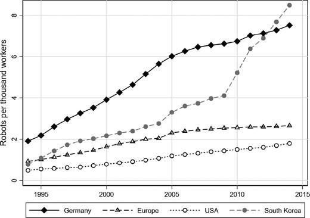

Robot penetration, 1994–2014. *Europe* = Germany, France, Italy, Spain, Finland, Sweden, Norway, and the United Kingdom. Robot penetration is the robot stock relative to the dependent employment in full-time equivalents (FTEs). Employment data from the IAB for Germany and from OECD.Stat for the remaining countries. Dependent employment in Korea was imputed from total employment and the ratio of dependent to total employment in the European countries, where data on both dependent and total employment are available. Source: IFR, OECD, BEH V10.01.00, and own calculations.

The first part of this paper replicates the strategy by Acemoglu and Restrepo (2019), who have found alarmingly negative impacts on labor demand in the United States. We find no such negative effects of predicted robot exposure on total employment in Germany, but show that this masks the presence of considerable *displacement* and *re-allocation* effects. Within manufacturing, predicted robot exposure leads to fewer jobs, but new labor demand in the service sector—in particular local services used by other businesses—leads to an offsetting force. We then extend the literature in three different ways, which we describe now.

The second main contribution of this paper is a complete characterization of the incidence of the displacement and re-allocation effects. The main finding is that the majority falls on young workers just entering the labor force. They face lower labor demand in automating industries and adjust by taking over jobs in the expanding service sector.<sup>2</sup> Incumbent workers, maybe paradoxically at first glance, actually see an *increase* in their plant tenure in response to more automation.

Our third main contribution shows that this latter effect—that is, automation causing more stable employment within firms—is driven by workers taking over new roles within their original plants. Displacement of old tasks, hence, takes place. However, it is swiftly offset by transitions of incumbent workers into new tasks for the same employer. Several measures indicate that those new jobs are of higher quality than the previous ones: The new occupations pay higher wages, are characterized by a larger share of abstract instead of routine tasks, and a higher college share. Young workers in local labor markets with more predicted exposure to automation also adapt their educational choices. They substitute away from vocational training toward colleges and universities. So, although the incidence of displacement out of manufacturing jobs falls mostly on young cohorts, the overall welfare effects of automation on young workers are less clear and might possibly be even positive in the longer term.<sup>3</sup>

Stated differently, we cannot detect evidence of skill-biased technological change. Automation mostly increases inequality *within* groups of ex-ante similar manufacturing workers. It creates large gaps between those who manage to stay at their original plant (thereby reaping the benefits of automation through longer tenure and higher wages) and those who are forced to leave their original employer, as they typically face an earnings drop and do not easily recover.

The theoretical implications of automation for wages, employment, and productivity have been studied by Acemoglu and Restrepo (2018b, 2019) and Moll, Restrepo, and Rachel (2019).<sup>4</sup> The important empirical paper by Acemoglu and Restrepo (2019) has documented negative effects of robots on wages and employment across US commuting zones, implying strong displacement forces and relatively weak offsetting productivity effects. Replicating this empirical strategy for Germany, we also find significant displacement effects, although around 50% smaller on average. The key difference, however, is that we additionally identify significant and offsetting re-allocation effects. Concerning the displacement effect, we find that it is concentrated in local labor markets with weaker labor protections (as measured by the strength of unions). This hints at the importance of labor market institutions in explaining how countries adapt differently to new technologies.

The data assembled by the International Federation of Robotics (IFR) was first exploited in the innovative paper by Graetz and Michaels (2018). Consistent with our results, they uncover positive productivity effects and zero effects on total employment, using variation in robot usage across industries in different countries. As our analysis shows, however, this zero overall employment impact can mask substantial displacement and re-allocation effects. We complement Graetz and Michaels (2018) (and also Acemoglu and Restrepo 2019) by providing the first study that leverages administrative labor market data. We can, therefore, investigate the underlying mechanisms in much greater detail; in particular, if workers separate from firms, how the set of tasks carried out by exposed workers evolves in response to automation, and what role the transitions of individual workers across industries and sectors play.<sup>5</sup>

An important part of the adjustment process to automation is the skill-upgrading process, as our evidence shows. Changes in the demand for high-skilled workers also feature prominently in the polarization literature (Autor and Dorn 2013; Goos et al. 2014; Michaels, Natraj, and van Reenen 2014). We document direct and indirect evidence for two margins of human capital adjustments to robots: first, for incumbent workers who are retained but transition into better jobs within their original plants, and, second, for young labor market entrants. The first channel of within-firm upgrading is consistent with the famous plant-level study by Bartel, Ichniowski, and Shaw (2007) on American valve-makers. They chronicle how the adoption of new IT-enhanced capital equipment leads to increases in the skill requirements of machine operators and a transition from routine to abstract/cognitive tasks.<sup>6</sup> Finally, our analysis reveals that the re-allocation effect is driven by increased employment in the business service sector, showing that the spillovers seem to operate locally through firms expanding their demand for complementary tasks. Relatedly, Helm (2019) also finds positive local spillovers of export shocks across German labor markets, consistent with agglomeration economies.

The remainder of this paper is organized as follows. Section 2 describes our empirical approach and the data. Section 3 studies the impact of robots on equilibrium employment, wages, and productivity across local labor markets. Sections 4 and 5 investigate adjustment mechanisms. Section 6 studies the adjustments of individual workers. Section 7 concludes.

## 2. Data and Methodology

### 2.1. Administrative Labor Market Data

Our main source is administrative German labor market data provided by the Institute for Employment Research (IAB) at the German Federal Employment Agency. Specifically, we use data from the Employee History (Beschäftigtenhistorik—BEH, Version 10.01.00). The raw version of the BEH is a spell-dataset of the complete job histories of the universe of private workers from 1978 to 2014, excluding the self-employed and civil servants. Eastern Germany enters the data in 1992. We use a simplified version of this dataset, which contains only one observation for each individual and year, pertaining to the spell of the highest paid job that stretches over June 30 of a given year.<sup>7</sup> The individual-level information contains information on gender, year of birth, educational attainment, a unique plant-id for the current workplace, as well as codes for industrial affiliation, location, and occupations.<sup>8</sup> This allows us to aggregate the dataset to the county level and obtain a precise picture on the size, the industry composition, and the workforce characteristics of local labor markets. Moreover, the worker-level panel structure of the dataset allows us to observe the mobility patterns of individuals as they enter the labor market, move between jobs, firms, industries, and regions, and, finally, when they exit the labor market. We mainly work at the level of local labor markets. Our main outcome is the percentage change in a county’s employment. We construct this from the aggregate worker counts on June 30 of the start year 1994 and the end year 2014, where part-time workers are weighted by 0.5 to get a measure for full-time equivalent employment. The information on the industry of the workplace plant allows us to construct this variable separately for the manufacturing and non-manufacturing sectors. The advantage of using percentage changes rather than the log-difference is that this growth rate can be decomposed into the contributions of various groups defined by worker mobility, such as workers who enter the labor market, workers who stay with their original plant, workers who move to a different plant in the same industry, and so forth.

Our second outcome variable is the log change in average wages. To construct this variable, we first impute the individual wages, which are censored at the social security contribution ceiling, using a procedure suggested by Card, Heining, and Kline (2013). We then compute the average daily wage for full-time workers on June 30 of the start and end years for demographic cells defined by gender, three age groups (below 30, 30–44, 45 or more years old), and three education groups (no or unknown degree, vocational training degree, university degree). A further dependent variable is the total annual wage bill, which is 365 times the individual daily wage, aggregated to the county level. To compare our results to the findings of Acemoglu and Restrepo (2019), we also construct the change in the employment-to-population ratio (*E/POP*) as a further outcome variable. The employment numbers again stem from the aggregate BEH data, while population counts stem from the German Federal Institute for Research on Building, Urban Affairs and Spatial Development (BBSR).<sup>9</sup>

### 2.2. Robot Usage

We combine our administrative labor market dataset with data on the stock of robots for 25 industries in 50 countries over the period from 1994 to 2014 from the International Federation of Robotics (IFR). This dataset has been used before by Graetz and Michaels (2018) in a cross-country study at the industry level and by Acemoglu and Restrepo (2019) for the United States. A *robot* in these data is defined as an “automatically controlled, re-programmable, and multipurpose machine”. As explained in more detail in International Federation of Robotics (2016), this means that robots are “fully autonomous machines that do not need a human operator and that can be programmed to perform several manual tasks such as welding, painting, assembling, handling materials, or packaging”. Single-purpose machines such as elevators or transportation bands are, by contrast, no robots in this definition, as they cannot be re-programmed to perform other tasks, require a human operator, or both. These data are based on yearly surveys of robot suppliers and capture around 90% of the world market. The information is broken down at the industry level.<sup>10</sup> The industry classification of these data conforms to two-digit ISIC Rev. 4 codes, where three-digit information is available for the manufacturing of electronic devices, electrical equipment, and motor vehicles. Since our administrative data have time-consistent NACE Rev. 2 industry codes, which correspond to the ISIC Rev. 4 codes at the two/three-digit level, both datasets can be matched without using any further crosswalk.<sup>11</sup>

The 25 industries consist of 20 manufacturing industries, agriculture, mining, electricity/gas/water supply, construction, and education. Appendix Figure A.1 illustrates the change in the number of robots per 1,000 workers in all 25 industries. We also present the US numbers there to facilitate a comparison. By far the strongest increase can be observed in the different branches of the automobile industry (motor vehicles, auto bodies and parts). Here, more than 100 additional robots were installed per 1,000 workers in 2014 compared to 1994. Other industries that became vastly more robot-intensive include rubber and plastic products, electronic components, and domestic appliances. On the other side of the spectrum, we find cases where robot usage has hardly changed, and sometimes (e.g. in manufacturing of instruments for measuring) it even decreased over time. In non-manufacturing industries, robots are used much less than in manufacturing.